# MSBMI 33200: Lecture 3

Anoop Mayampurath

10/18/2019

## Midterm project-proposal

Proposal for creating and delivering your final project in this class

Due date: October 28, 2019

Final presentations : Week 9

## Proposal requirements

1. 1 page
2. Includes Title, Introduction, Data, Proposed Methods, and Timeline

## Section details

Introduction: you must introduce the background behind the dataset.

Here is a tip: start broad. Then try to narrow the focus of the reader with every sentence until the last. A great ending to the introduction would be along the lines of “My hypothesis is that..” or “The objective of this project is to..”

Data : mention source of the data, number of samples, number of predictors, and details about training-testing split.

Proposed Methods: Summarize how you are going to accomplish your objective. Be reasonably thorough. Don’t try to over-achieve. The best projects are usually where both you and the audience learn something new.

Timeline : split into the following categories: data cleaning, modeling/interpretation, and presentation work.

## Non-linear models

Non-linear models relax the linearity assumption between the outcome and the predictors. We will learn about this in stages as polynomial regression, step functions, spline-based and generalized additive models.

## Polynomial regression

In polynomial regression, we simply add extra predictors by increasing the power of a single predictor.

For example, consider a single-feature linear prediction model.

$$y = w_{0} + w_1x_1$$
A cubic (i.e., degree=3) regression would be

$$y = w_{0} + w_1x_1 + w_2x_1^2 + w_3x_1^3$$
Typically, we don’t go beyond a degree of 3 or 4, since these can be senstive to boundary values of X.

A polynomial of degree $d$ has $d$ degrees of freedom.

## Step functions

Here, we divide $x$ into $K$ bins based on cutpoints $c_1, c_2, \dots c_K$. In other words, we convert a numeric variable into an ordered categorical variables.

We then model

$$y = w_{0} + w_1C_1(x_1) + w_2C_2(x_1) + \dots + w_KC_K(x_1)$$

where $C_k(x) = I(c_{k-1} \leq x \leq c_{k})$

In other words, we fit a constant to each bin.

We can do this for a logistic regression model too

$$P(y=1) = \frac{exp(w_{0} + w_1C_1(x_1) + w_2C_2(x_1) + \dots + w_KC_K(x_1))}{1+ exp(w_{0} + w_1C_1(x_1) + w_2C_2(x_1) + \dots + w_KC_K(x_1))}$$

The disadvantage of this method is that local non-linearity is not capture because we are fitting a constant to each bin

Here is an example (source ISLR)

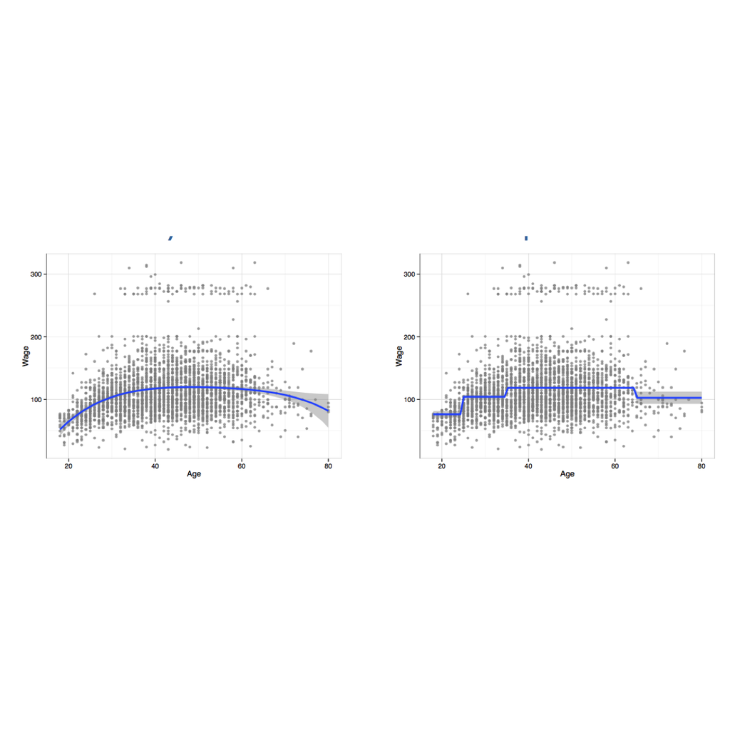

## Spline-based models

Instead of fitting one high-degree polynomial over all $x$, we perform a piecewise polynomial fit where we fit a polynomical to each bin.

As an example, consider a single predictor where we use a single cutpoint $c$. To develop a spline-based model, we fit two different polynomials to the data. Below we fit two different cubic polynomials

$$y=
\begin{cases}
w_{01} + w_{11}x_1 + w_{21}x_1^2 + w_{31}x_1^3,& \text{if } x_1 < c\\
w_{02} + w_{12}x_1 + w_{22}x_1^2 + w_{32}x_1^3,& \text{if } x_1 \geq c
\end{cases}$$

The cutpoint are called knots. Generally speaking, increasing the number of knots increases the flexibility of the piecewise polynomial fit.

The drawback of using knots is that the piecewise polynomials may not be connected at the knots. Thus, we need to constraint the fit so that fitted cubic spline must be continous. We do this by including the constraint that the first and second derivatives of the piecewise polynomials are continous at knots.

Here is an example (source: ISLR)

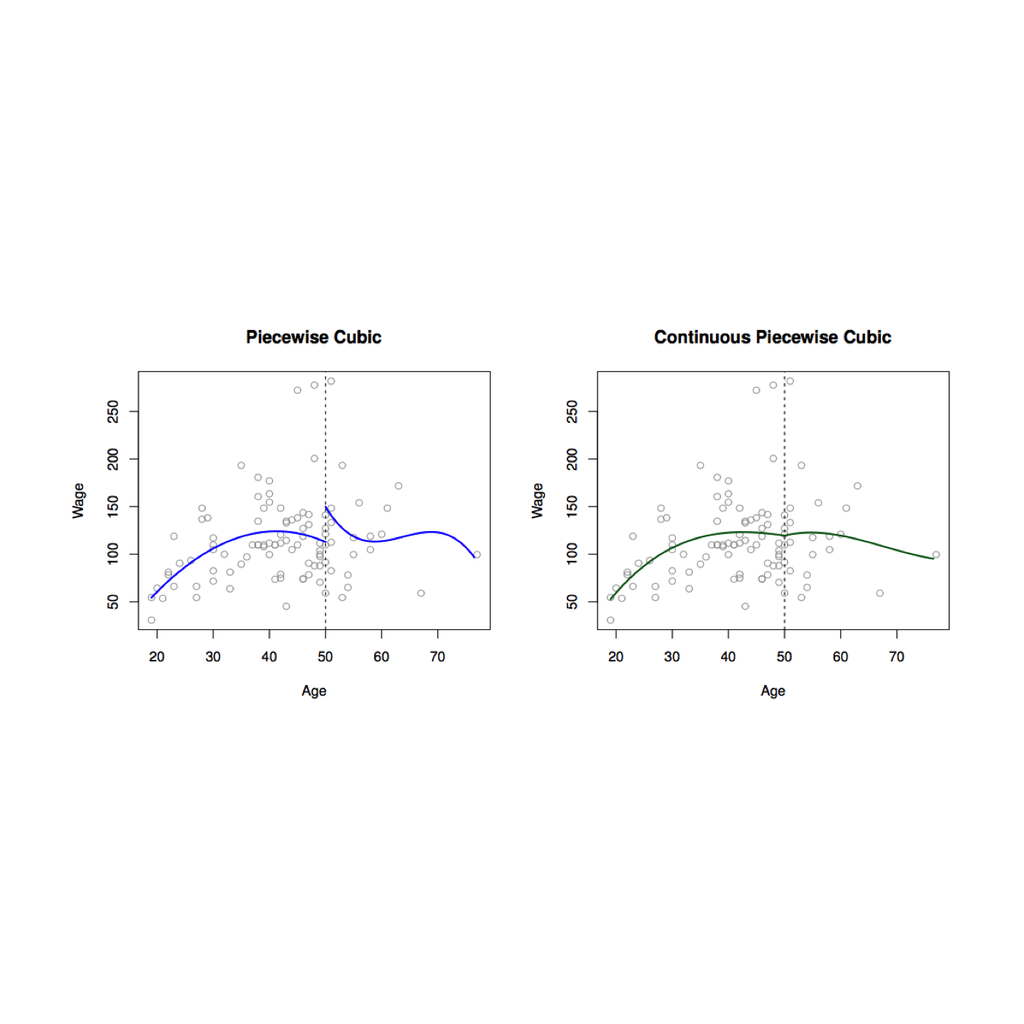

## Cubic Splines

Consider a single predictor binned into $K$ knots. We fit a cubic spline with a continous restriction by fitting:

$$y = w_{0} + w_1x_1 + w_2x_1^2 + w_3x_1^3 + w_4h(x_1, \epsilon_1) + w_5h(x_1, \epsilon_2) + \dots w_{K+3}h(x_1, \epsilon_K)$$

where
$$\epsilon_1, \epsilon_2, \dots, \epsilon_K$$
are the knots, and

$$h(x, \epsilon)=
\begin{cases}
(x-\epsilon)^3, \text{if } x > \epsilon \\
0, \text{otherwise}
\end{cases}$$

We need to choose:

1. The number of knots: this is chosen using cross validation
2. The placement of knots: We can place the knots based on the expected variation in the variable. Otherwise, we can place them at equal intervals, such as quantiles.

## Restricted Cubic Splines

This also improves the performance of the model in terms of fitting the tails of $x_1$

## Generalized Additive Models (GAMs)

GAMs extend the above approaches to handling non-linearity in one variable to multiple variables.

We replace each variable by a non-linear function of that variable but retain the additivity.

The general framework of a GAM for linear regression is given by:

$$y = w_0 + \sum_{j=1}^{p}f_j(x_j)$$

Thus, each variable $x_j$ is converted to a $f_j(x_j)$ that is unique to that variable.

The function $f_j(x_j)$ is your choice for that variable: polynomial, step-function, cubic spline, degree-$k+1$ spline etc.

For logistic regression, the framework becomes

$$logit(P(y=1)) = w_0 + \sum_{j=1}^{p}f_j(x_j)$$

## K-Nearest Neighbors Classification Algorithm

K-Nearest Neighbors (KNN) classifiers are very simple and intuitive. For a test data point $x_i$, the algorithm finds the K-closest neighbors to that data point (assembled to belong to a set $N_K$). Then it calculates

$$P(y_i=c) = \frac{1}{K} \sum_{k \in N_K} I(y_k = c)$$
In other words, it calculates the frequency of the each class label within $N_K$. Class labels are assigned based on which $j$ corresponds to maximum of $P(y_i=j)$

## Dependence on $K$

The performance of KNN is hugely dependent on $K$. The best way to choose $K$ is to use cross-validation

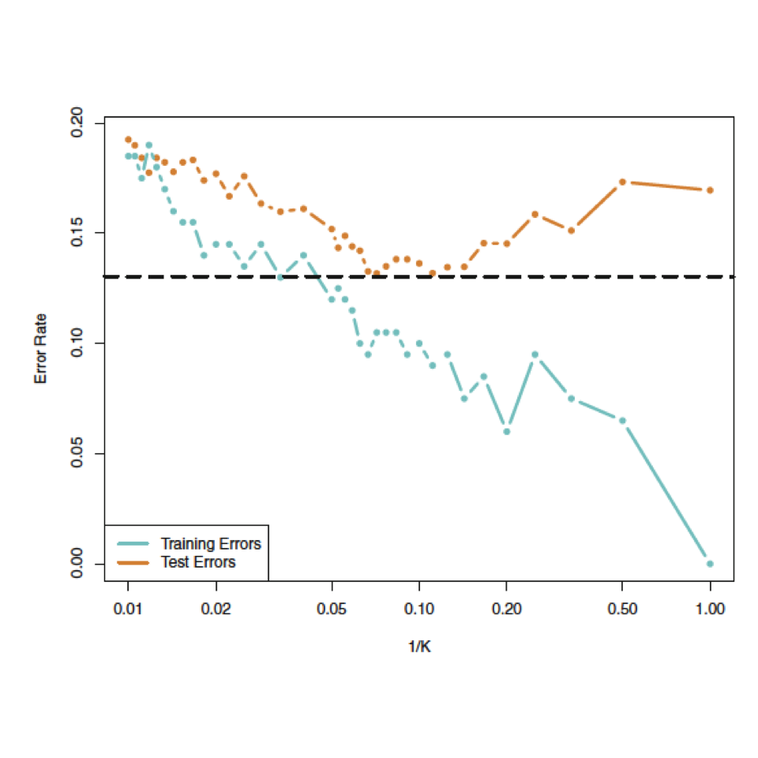

## Model Selection

We’ve covered multiple ways of choosing the best model based on measuring test error using MSE and $R^2$ for regression models and AUC and Sensitivity/Specificity for classification models.

The other two that are used to choose models are:

1. Akaike Information Criteria (AIC), defined for a model $M$ as

$AIC(M) = - logLik(M) + dim(M)$

where,

- $logLik(M)$ is the log-likelihood of the model $M$, evaluated at the maximum likelihood estimate. This is an indication of goodness-of-fit.
- $dim(M)$ is the number of parameters of the model. This is an indication of model complexity.

The rule is to choose the model that has lower $AIC$. AIC offers a balance between choosing a model that fits the data very well and the complexity of the model.

2. Bayesian Information Criteria (BIC), defined for a model $M$ as

$BIC(M) = - logLik(M) + \frac{log n}{2} dim(M)$

where,  
- $logLik(M)$ and $dim(M)$ are the same as definitions in AIC.  
- $n$ is the number of observations.

BIC has a stronger penalty and is shown to be better at picking the true model as $n \to \infty$.

Both AIC and BIC show equivalence to cross-validation asymptotically.

## Variable selection

In the ML world there are a few techniques to choose the list of important variables. While you should never (!) use these methods, you should be aware of them. They are called stepwise techniques.

## Forward Stepwise Selection

Basic idea: Sequentially add variables, while ensuring that the best model is chosen with each addition

Steps:

1. Let $M_0$ denote null model, which contains no predictors.
2. For $k = 1, 2, \dots p$:  
   (a) Fit all $p-(k-1)$ models that augments the predictors in $M_{k-1}$ with exactly one predictor on training data.  
   (b) Choose the best model for using RSS on the training data. Call it $M_k$.
3. Select the best model from $M_{0}, M_{1}, \dots M_{p}$ using validaton techniques on test data.

Once again, training error is minimized in Step 2 and test error is minimized in Step 3.

Choice of best possible models is not guaranteed.

## Backward stepwise selection

Basic idea: Sequentially delete variables, while ensuring that the best model is chosen with each deletion.

Steps:

1. Let $M_p$ denote full model, which contains $p$ predictors.
2. For $k = p-1, p-2, \dots 0$:  
   (a) Fit all $k$ models that contains all but one of the predictors in $M_{k+1}$ on training data.  
   (b) Choose the best model for using RSS on the training data. Call it $M_k$.
3. Select the best model from $M_{0}, M_{1}, \dots M_{p}$ using validaton techniques on test data.

Similar to forward selection in terms of minimizing training and test error, and lack of guarantee of reaching the best model.

Hybrid methods exists where you start with forward selection, but after choice of the best model within Step 2, you run backward selection to remove irrelevant variables.

We can also replace using RSS in Step 2 with cross-validation. But we will keep aside a separate test set to minimize test error (or validation error)

## Why you should not use stepwise techniques.

Frank Harell (2001) from Regression Modeling Strategies (see https://www.stata.com/support/faqs/statistics/stepwise-regression-problems/)

1. It yields R-squared values that are badly biased to be high.
2. The F and chi-squared tests for each variable do not have the claimed distribution.
3. The method yields confidence intervals for effects and predicted values that are falsely narrow; see Altman and Andersen (1989).
4. It yields p-values that do not have the proper meaning, and the proper correction for them is a difficult problem.
5. It gives biased regression coefficients that need shrinkage (the coefficients for remaining variables are too large; see Tibshirani [1996]).
6. It has severe problems in the presence of collinearity.
7. It is based on methods (e.g., F tests for nested models) that were intended to be used to test prespecified hypotheses.

## Variable Importance

Variable importance plots gives you a sense of what variables are important for predictions. However, these are used for sanity checks and for explaining the model and NOT for feature selection.

For linear models, variable importance is simply the t-statistic for each variable. But for other models such as randomn forests, you can get a sense of variable importance with respect to the model as well.

For further details, see https://topepo.github.io/caret/variable-importance.html

## Understanding model predictions

You can also get a sense of what features are important by looking at the test predictions.

One popular method is the partial dependence plots (Friedman 2001). This depicts the marginal effect of single predictors by measuring the change in average predicted probability as the predictor varies. If the line is a constant or near-constant near 0, then the variable has no or little impact on the model.

A recent tool that does this better is LIME (Ribeiro 2016). LIME is model-agnostic (https://arxiv.org/abs/1602.04938)

The idea is simple and as follows.

1. Generate fake data by permuting observations.
2. Calculate distance between these new permuted observations and the true observation.
3. Make predictions using your model $M$
4. Pick a handful of features that is most informative in terms to driving the predictions correctly.
5. Use these features and distance metrics as weights to fit a simple model
6. And use those final weights to explain the model for that observation.

Ultimately, you will get a plot like this (source: https://github.com/marcotcr/lime)

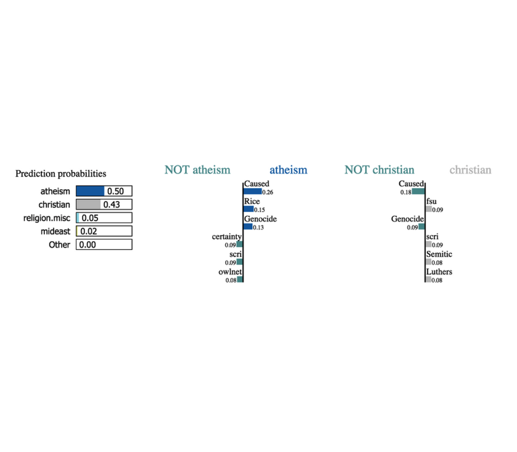